# Schmidt_Emily_TP5

Emily Schmidt

2023-04-05

# 1 Midterm Exercise - International Tourists to Australia

This exercise is intended to allow you the revisit different topics covered in the first half of the semester in the course, ”Forecasting with Applications in Business”.

## 1.1 Libraries

```r
#library(fpp2)
library(fpp3)
library(zoo)
library(ggplot2)
library(tsibble)
```

## 1.2 Load and Explore Data

**Description**: Quarterly visitor nights (in millions) spent by international tourists to Australia. 1999-2015, quarterly.

```r
tourist = read.csv("tourist.csv", header = TRUE)

# Coerce POSIXct/Dates to yearquarter
x <- seq(as.Date("1999-01-01"), as.Date("2015-12-31"), by = "quarter") # Represent year-quarter
time <- yearquarter(x, fiscal_start = 1) # Add variable to time, use in tsibble/data frame

tourist$Time = time
tourist = as_tsibble(tourist, index = Time) # Convert the data frame to a tsibble object
```

Within Section 2.1 of the book, it states that “a time series can be thought of as a list of numbers (the measurements), along with some information about what times those numbers were recorded (the index).” Here, the index is “year quarter” and the measurement is the number of tourists in millions.

# 2 Question A

Plot the selected time series and comment the general features you can observe.

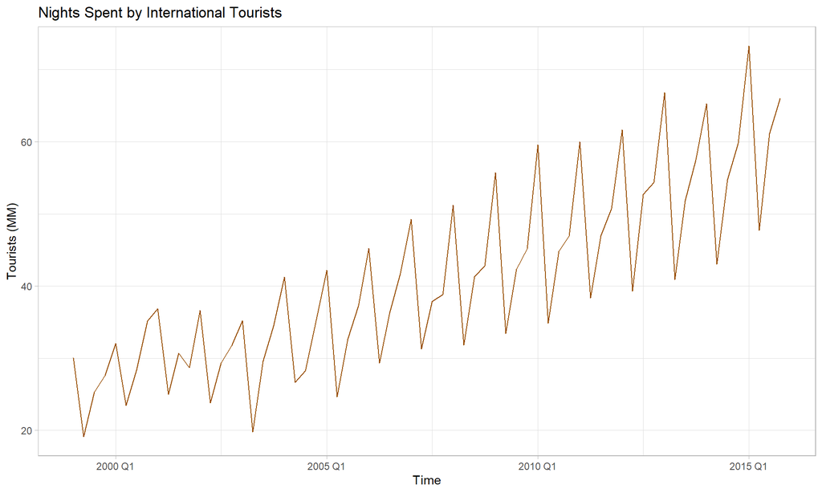

```r
# Plot the Australian tourist data
ggplot(tourist) +
  geom_line(aes(Time,Tourists), color = "#964B00") +
  labs(title = "Nights Spent by International Tourists", x = "Time", y = "Tourists (MM)") +
  theme_light()
```

There are four components considered when analyzing time series data:

• Trend: A long-term increase or decrease in the data; a “changing direction”.

• Seasonality: A seasonal pattern of a fixed and known period. If the frequency is unchanging and associated with some aspect of the calendar, then the pattern is seasonal.

• Cycle: A rise and fall pattern not of a fixed frequency. If the fluctuations are not of a fixed frequency, then they are cyclic.

• Random: Remainder of what is not included in the other three components.

**Note**: Seasonal vs Cyclic: In general, cyclic patterns are longer and more variable than seasonal patterns.

From these main elements, we notice several observations. The trend appears to be generally increasing. Strong seasonality occurs because of the relative structure of how each year follows a very similar pattern. Since the data is from Australia, their busiest seasons are their warmer months. This would include the first and fourth quarters. In the first five years, the seasonality component is different than anything past 2005 Q1. Real life events such as the 2000 Sydney Olympics and 2003 Rugby World Cup could have played an important role. This can be seen through the amplitudes stagnation during those couple of years when those festivities stopped in 2003. If there is presence of cyclic behavior, it would be difficult to see since seasonality dominates the series. Other than cyclic behavior being hard to analyze or non-existent, the random fluctuations should be reviewed a different way.

Since the size of the seasonal and randomness amplitudes between periods continues to increase with the level of time series, a multiplicative model may be the best method. To quickly check this, a transformation of the series can be calculated that shows the following:

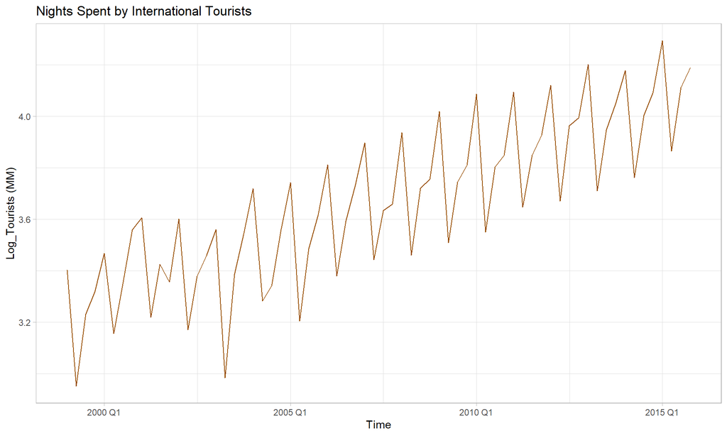

```r
# Log transformation of Tourist
ggplot(tourist) +
  geom_line(aes(Time,log(tourist$Tourists)), color = "#964B00") +
  labs(title = "Nights Spent by International Tourists", x = "Time", y = "Log_Tourists (MM)") +
  theme_light()
```

By transforming the ‘Tourists’ variable, this can help stabilize the variance (randomness). This is easily seen by how the amplitudes for seasonality become more consistent over time since they appear to increase at a slower rate, if at all.

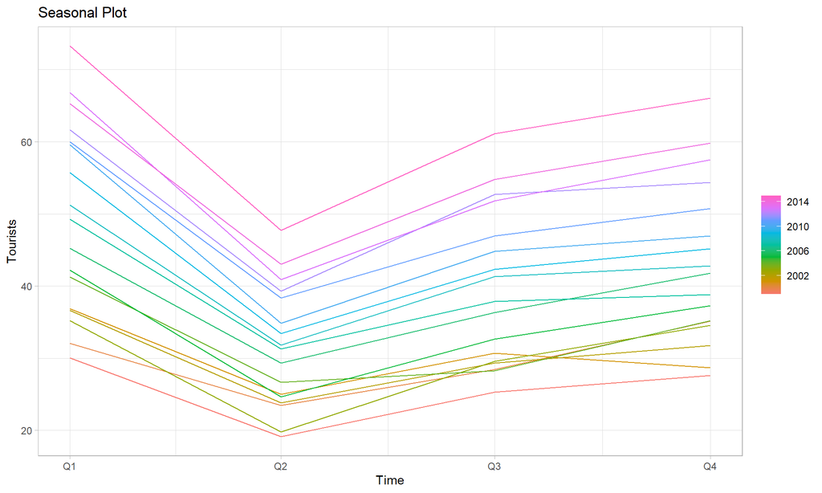

```r
# Seasonal Plot (Chapter 2.4)
gg_season(tourist) + theme_light() + labs(title = "Seasonal Plot")
```

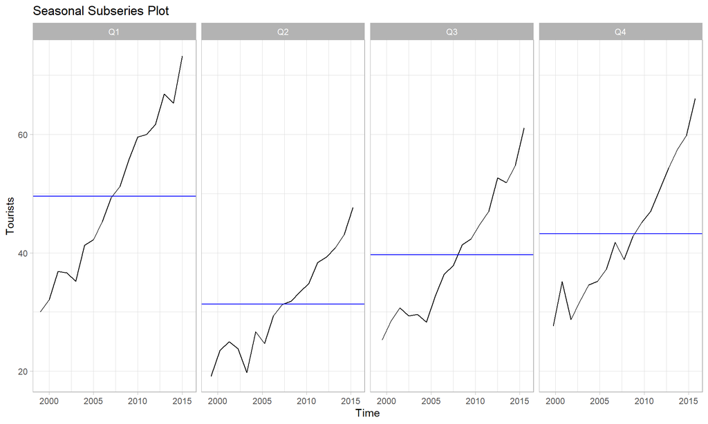

```r
#  Seasonal Subseries Plot (Chapter 2.5)
gg_subseries(tourist) + theme_light() + labs(title = "Seasonal Subseries Plot")
```

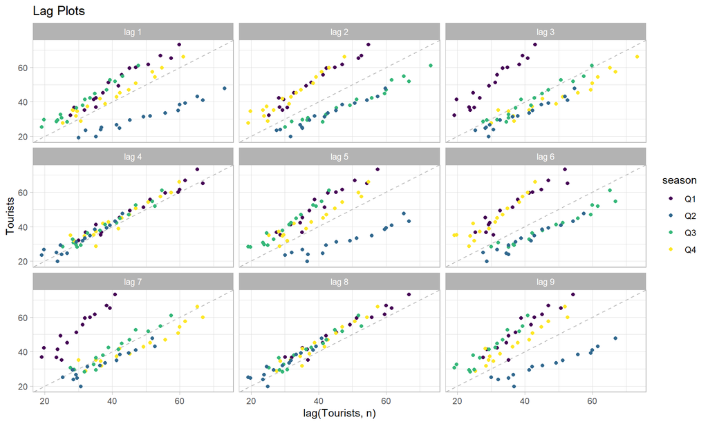

```r
# Lag Plots (Chapter 2.7)
gg_lag(tourist, geom = "point") + theme_light() + labs(title = "Lag Plots")
```

```r
tourist |> ACF(lag_max = 9)
```

```
## # A tsibble: 9 x 2 [1Q]
##        lag   acf
##   <cf_lag> <dbl>
## 1       1Q 0.540
## 2       2Q 0.522
## 3       3Q 0.499
## 4       4Q 0.819
## 5       5Q 0.409
## 6       6Q 0.398
## 7       7Q 0.384
## 8       8Q 0.706
## 9       9Q 0.316
```

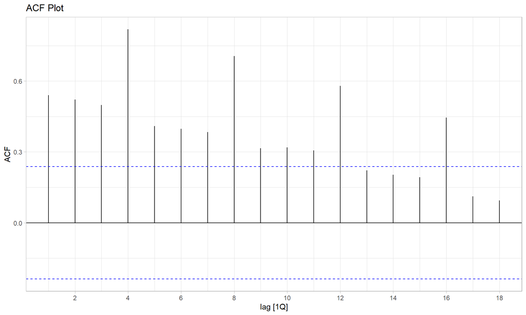

```r
# ACF Plot (Chapter 2.8)
tourist |> ACF() |>  autoplot() + theme_light() + labs(title = "ACF Plot", y = "ACF")
```

*Seasonal Plot*  
According to Chapter 2.4, a seasonal plot mimics a time plot except that the data are plotted against the individual “seasons.” Within the Seasonal Plot, there is data from each season that can overlap. As mentioned earlier, the summer months for Australia are their peak seasons. Therefore, Q1 and Q4 have much more overnight tourists than Q2 and Q3. As the series evolves, the change from one season to another is more drastic. For example, analyze the bottom red line from Q1 to Q2 and compare that same time period to the most recent year, 2015. The change between those periods significantly widened. Similar effects can be seen between Q2 to Q3 and Q3 to Q4, but they are not as prominent. Overall, this plot paints a clear picture, identifying years that seasonality changes.

*Autocorrelation Plot*  
Chapter 2.8 states that autocorrelation measures the linear relationship between lagged values of a time series. Prior to plotting the autocorrelation, there is a tsibble object that corresponds to the nine scatterplots. We typically plot the ACF to see how the correlations change with the lag $k$. Within the correlogram, it is seen that the autocorrelations are larger for the seasonal lags which occur quarterly. Additionally, when a trend is present, which is the case here, the autocorrelations for small lags tend to be large and positive. This can be observed at $r^4$, $r^8$, $r^{12}$ and $r^{16}$, representing the quarters. There appears to be no white noise which would mean the time series shows no autocorrelation.

# 3 Question B

Apply both the decomposition methods seen in class and plot the results. Comment the results of these two procedures.

## 3.1 Classical Decomposition

```r
# Additive decomposition (TP 1)
tourist |>
  model(
    classical_decomposition(Tourists, type = "additive")) -> decomp_add

addit <- components(decomp_add)
addit
```

```
## # A dable: 68 x 7 [1Q]
## # Key:     .model [1]
## # :        Tourists = trend + seasonal + random
##    .model                              Time Touri…¹ trend seaso…² random seaso…³
##    <chr>                              <qtr>   <dbl> <dbl>   <dbl>  <dbl>   <dbl>
##  1 "classical_decomposition(Touris… 1999 Q1    30.1  NA      9.78 NA        20.3
##  2 "classical_decomposition(Touris… 1999 Q2    19.1  NA     -9.47 NA        28.6
##  3 "classical_decomposition(Touris… 1999 Q3    25.3  25.8   -1.59  1.13     26.9
##  4 "classical_decomposition(Touris… 1999 Q4    27.6  26.6    1.28 -0.262    26.3
##  5 "classical_decomposition(Touris… 2000 Q1    32.1  27.5    9.78 -5.22     22.3
##  6 "classical_decomposition(Touris… 2000 Q2    23.5  28.8   -9.47  4.11     33.0
##  7 "classical_decomposition(Touris… 2000 Q3    28.5  30.4   -1.59 -0.322    30.1
##  8 "classical_decomposition(Touris… 2000 Q4    35.1  31.2    1.28  2.67     33.8
##  9 "classical_decomposition(Touris… 2001 Q1    36.8  31.6    9.78 -4.59     27.1
## 10 "classical_decomposition(Touris… 2001 Q2    25.0  31.1   -9.47  3.36     34.5
## # … with 58 more rows, and abbreviated variable names ¹Tourists, ²seasonal,
## #   ³season_adjust
```

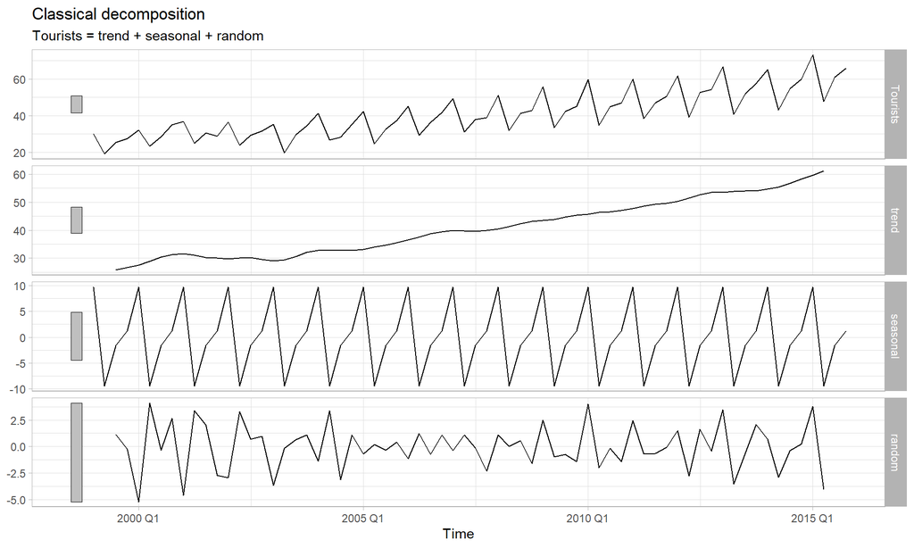

```r
addit |> autoplot() + theme_light()
```

Classical decomposition has two forms, additive and multiplicative. We will start with analyzing the additive approach ($y_t = S_t + T_t + R_t$). Each structure can describe a time series with seasonal period $m$, which would be $m = 4$ for the the international visitors spending nights in Australia on a quarterly basis. Specific to seasonality, it is assumed that the component is constant year to year. Since $m$ is an even number, the trend-cycle element $\hat{T_t}$ needs to be computed using 2 x $m$-MA. Once that value is found, the detrended series can be found through $y_t - \hat{T_t}$. To find $\hat{S_t}$, average the detrended values for that season, which should be applied to ensure that they add to zero. Those components then are summed for each year of the data. Having those two main components, the remainder can be estimated: $\hat{R_t}\ = y_t - \hat{T_t}\ - \hat{S_t}$.

The trend is mostly linear and positive after five-ish years from 2000. Towards the end of the slope though in 2015, there appears to be a steeper incline which could be due to a multiplicative effect. The seasonality remains consistent, which is not supposed to be the case. The random component though shows signs of patterns, which is problematic because we want to isolate the components since we want to know what cannot be explained.

```r
# Multiplicative decomposition (TP 1)
tourist |>
  model(classical_decomposition(
    Tourists, type = "multiplicative")) -> decomp_mult

mult <- components(decomp_mult)
mult
```

```
## # A dable: 68 x 7 [1Q]
## # Key:     .model [1]
## # :        Tourists = trend * seasonal * random
##    .model                              Time Touri…¹ trend seaso…² random seaso…³
##    <chr>                              <qtr>   <dbl> <dbl>   <dbl>  <dbl>   <dbl>
##  1 "classical_decomposition(Touris… 1999 Q1    30.1  NA     1.24  NA        24.3
##  2 "classical_decomposition(Touris… 1999 Q2    19.1  NA     0.772 NA        24.8
##  3 "classical_decomposition(Touris… 1999 Q3    25.3  25.8   0.959  1.02     26.4
##  4 "classical_decomposition(Touris… 1999 Q4    27.6  26.6   1.03   1.00     26.7
##  5 "classical_decomposition(Touris… 2000 Q1    32.1  27.5   1.24   0.943    26.0
##  6 "classical_decomposition(Touris… 2000 Q2    23.5  28.8   0.772  1.06     30.4
##  7 "classical_decomposition(Touris… 2000 Q3    28.5  30.4   0.959  0.977    29.7
##  8 "classical_decomposition(Touris… 2000 Q4    35.1  31.2   1.03   1.09     34.0
##  9 "classical_decomposition(Touris… 2001 Q1    36.8  31.6   1.24   0.942    29.8
## 10 "classical_decomposition(Touris… 2001 Q2    25.0  31.1   0.772  1.04     32.4
## # … with 58 more rows, and abbreviated variable names ¹Tourists, ²seasonal,
## #   ³season_adjust
```

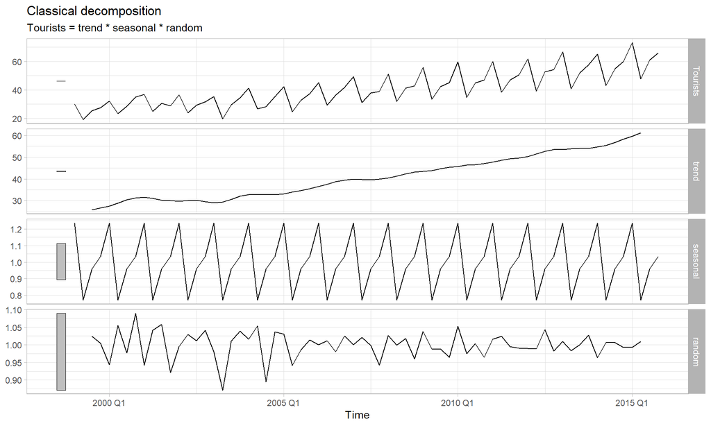

```r
mult |>  autoplot() + theme_light()
```

**Note**: Keep in mind that classical decomposition is not recommended when choosing a method. Please see Section 3.4 for more details. Therefore, other models will be explored.

Although we will not dive into $m$-MA, I wanted to give a quick outline of moving averages of moving averages since we need to make an even-order moving average symmetric if additional analyses were to be conducted. Section 3.3 mentions how using “a 2-MA follows a moving average of an even order (such as 4), it is called a ‘centered moving average of order 4.’”

```r
tourist_MA <- tourist |>
  filter(year(Time) >= 1999) |>
  select(Time, Tourists)
tourist_MAMA <- tourist |>
  mutate(
    `4-MA` = slider::slide_dbl(Tourists, mean,
                .before = 1, .after = 2, .complete = TRUE),
    `2x4-MA` = slider::slide_dbl(`4-MA`, mean,
                .before = 1, .after = 0, .complete = TRUE)
  )
tourist_MAMA
```

```
## # A tsibble: 68 x 4 [1Q]
##       Time Tourists `4-MA` `2x4-MA`
##      <qtr>    <dbl>  <dbl>    <dbl>
##  1 1999 Q1     30.1   NA       NA
##  2 1999 Q2     19.1   25.5     NA
##  3 1999 Q3     25.3   26.0     25.8
##  4 1999 Q4     27.6   27.1     26.6
##  5 2000 Q1     32.1   27.9     27.5
##  6 2000 Q2     23.5   29.8     28.8
##  7 2000 Q3     28.5   31.0     30.4
##  8 2000 Q4     35.1   31.4     31.2
##  9 2001 Q1     36.8   31.9     31.6
## 10 2001 Q2     25.0   30.3     31.1
## # … with 58 more rows
```

## 3.2 STL Decomposition

```r
# SLT additive decomposition, 3.6 SLT Decomposition
tourist |>
    model(
      STL(Tourists ~ trend(window = 5) + season(window = 5),  # 5 due to quarterly data
          robust = TRUE)) -> decomp_stl_add

stl_add <- components(decomp_stl_add) #season_adjust = y_t - s_t
stl_add
```

```
## # A dable: 68 x 7 [1Q]
## # Key:     .model [1]
## # :        Tourists = trend + season_year + remainder
##    .model                           Time Touri…¹ trend seaso…² remainder seaso…³
##    <chr>                           <qtr>   <dbl> <dbl>   <dbl>     <dbl>   <dbl>
##  1 STL(Tourists ~ trend(window … 1999 Q1    30.1  24.5   5.63  -1.24e- 1    24.4
##  2 STL(Tourists ~ trend(window … 1999 Q2    19.1  25.2  -6.23   1.81e- 1    25.4
##  3 STL(Tourists ~ trend(window … 1999 Q3    25.3  25.8  -0.841  3.51e- 1    26.2
##  4 STL(Tourists ~ trend(window … 1999 Q4    27.6  26.2   1.46  -4.85e- 2    26.1
##  5 STL(Tourists ~ trend(window … 2000 Q1    32.1  26.4   5.64  -7.11e-15    26.4
##  6 STL(Tourists ~ trend(window … 2000 Q2    23.5  27.9  -6.29   1.90e+ 0    29.8
##  7 STL(Tourists ~ trend(window … 2000 Q3    28.5  29.3  -0.851  0           29.3
##  8 STL(Tourists ~ trend(window … 2000 Q4    35.1  30.2   1.54   3.33e+ 0    33.6
##  9 STL(Tourists ~ trend(window … 2001 Q1    36.8  31.2   5.67   7.11e-14    31.2
## 10 STL(Tourists ~ trend(window … 2001 Q2    25.0  31.5  -6.58   8.40e- 2    31.6
## # … with 58 more rows, and abbreviated variable names ¹Tourists, ²season_year,
## #   ³season_adjust
```

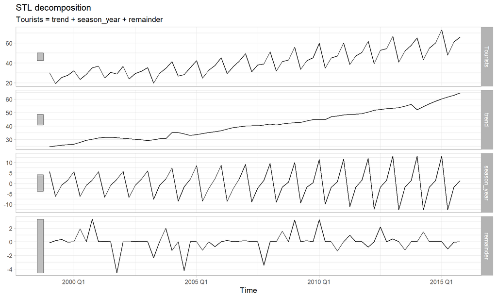

```r
stl_add |>  autoplot() + theme_light()
```

Here is the transformed Australian quarterly international night tourists with the $\lambda$ (0.06) parameter chosen using the Guerrero method. Section 3.1 outlines that a “good value of $\lambda$ is one which makes the size of the seasonal variation about the same across the whole series, as that makes the forecasting model simpler.”

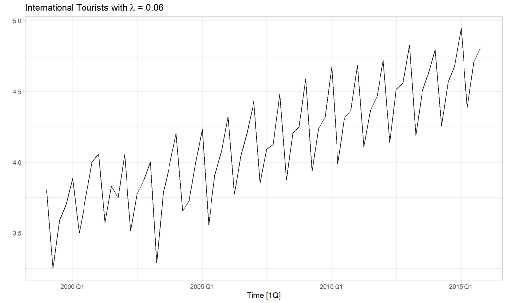

```r
# 3.1 Transformations and Adjustments
#A Box Cox transform was applied to the STL model to extract a single seasonal component
lambda <- tourist |>
  features(tourist$Tourists, features = guerrero) |>
  pull(lambda_guerrero)

tourist |>
  autoplot(box_cox(Tourists, lambda)) +
  labs(y = "",
       title = latex2exp::TeX(paste0(
         "International Tourists with $\\lambda$ = ",
         round(lambda,2)))) + theme_light()
```

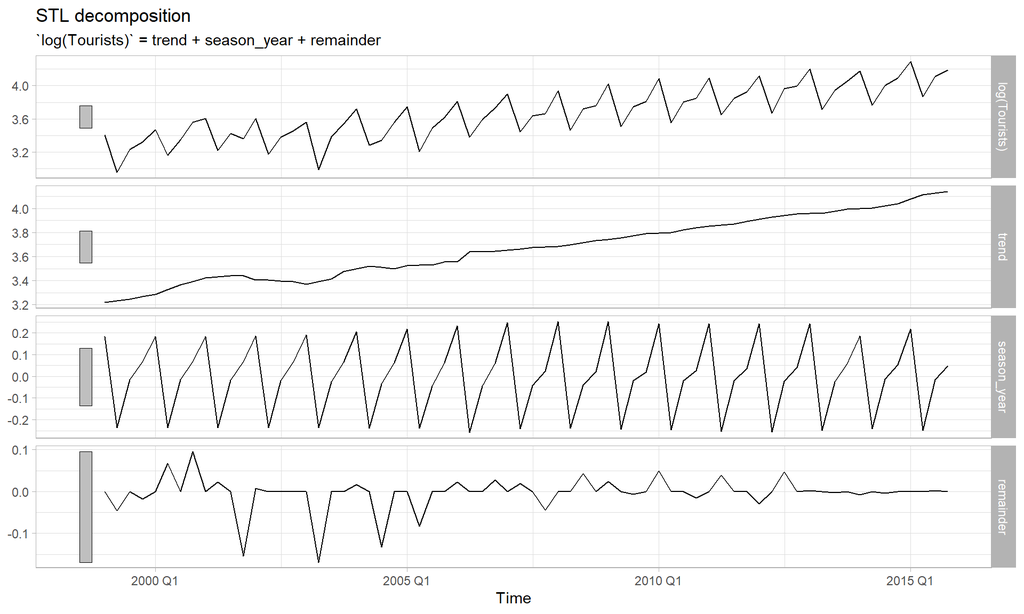

```r
# SLT additive decomposition, 3.6 SLT Decomposition
tourist |>
    model(
      STL(log(Tourists) ~ trend(window = 5) + season(window = 5),  # 5 due to quarterly data
          robust = TRUE)) -> decomp_stl_mult

stl_mult <- components(decomp_stl_mult) #season_adjust = y_t - s_t

stl_mult |>  autoplot() + theme_light()
```

Compared to the classical decompositions, the STL is a robust and versatile method. There are additional features that can be used within the function, giving the flexibility to alter the parameters to see how the trend-cycle and seasonal change the time series components. These two windows can be described as the following:

• Trend-cycle window: The number of consecutive observations to be used when estimating the trend-cycle

• Season window: The number of consecutive years to be used in estimating each value in the seasonal component

For both parameters, an odd number should be used. Also, note that a smaller value will allow for more rapid changes. For instance, we increasing the trend window to 68, we obtain just a straight line.

The STL model uses an additive approach. Earlier in the classical decomposition, there was an issue with the random component in the additive method due to patterns in the remainder. Therefore, it is important to also obtain a multiplicative model. To create this model, one needs to take the ‘logs of the data then back-transforming the components’ because the data shows variation that increases with the level of the series. Within both SLT models, the trend is positive. But, when comparing SLT versus SLT transformed, they have different peaks or dips that are more distinct depending on which model is used. The seasonality of the additive STL continues to grow as the amplitude increases over time while the multiplicative takes that more into account. With the log transformed model, the seasonal pattern slightly changes from Q3 to Q4 because it appears to be more constant when the series continues. The random component in the second approach does not show any patterns while the additive method does. Out of the four models, the STL multiplicative method may be the most relevant since the seasonal variation increases over time.

## 3.3 Extracted Trends

```r
# Trend from additive decomposition
components(decomp_add) |>
  na.omit() |>
  select(Time, trend) -> addit_trend_coef

# Trend from multiplicative decomposition
components(decomp_mult) |>
  na.omit() |>
  select(Time, trend) -> mult_trend_coef

# Trend from STL additive decomposition
components(decomp_stl_add) |>
  na.omit() |>
  select(Time, trend) -> stl_trend_coef

# Trend from STL multiplicative (log) decomposition
components(decomp_stl_mult) |>
  na.omit() |>
  select(Time, trend) -> stl_log_trend_coef

bind_cols(addit_trend_coef,
          mult_trend_coef[,2],
          stl_trend_coef[3:66, 2],
          stl_log_trend_coef[3:66, 2])
```

```
## # A tsibble: 64 x 5 [1Q]
##       Time trend...2 trend...3 trend...4 trend...5
##      <qtr>     <dbl>     <dbl>     <dbl>     <dbl>
##  1 1999 Q3      25.8      25.8      25.8      3.25
##  2 1999 Q4      26.6      26.6      26.2      3.27
##  3 2000 Q1      27.5      27.5      26.4      3.28
##  4 2000 Q2      28.8      28.8      27.9      3.32
##  5 2000 Q3      30.4      30.4      29.3      3.37
##  6 2000 Q4      31.2      31.2      30.2      3.39
##  7 2001 Q1      31.6      31.6      31.2      3.42
##  8 2001 Q2      31.1      31.1      31.5      3.43
##  9 2001 Q3      30.3      30.3      31.7      3.44
## 10 2001 Q4      30.1      30.1      31.3      3.44
## # … with 54 more rows
```

```r
# Note: Look at decomposition mult model, trend does has two NAs so 68 - 2 = 66
```

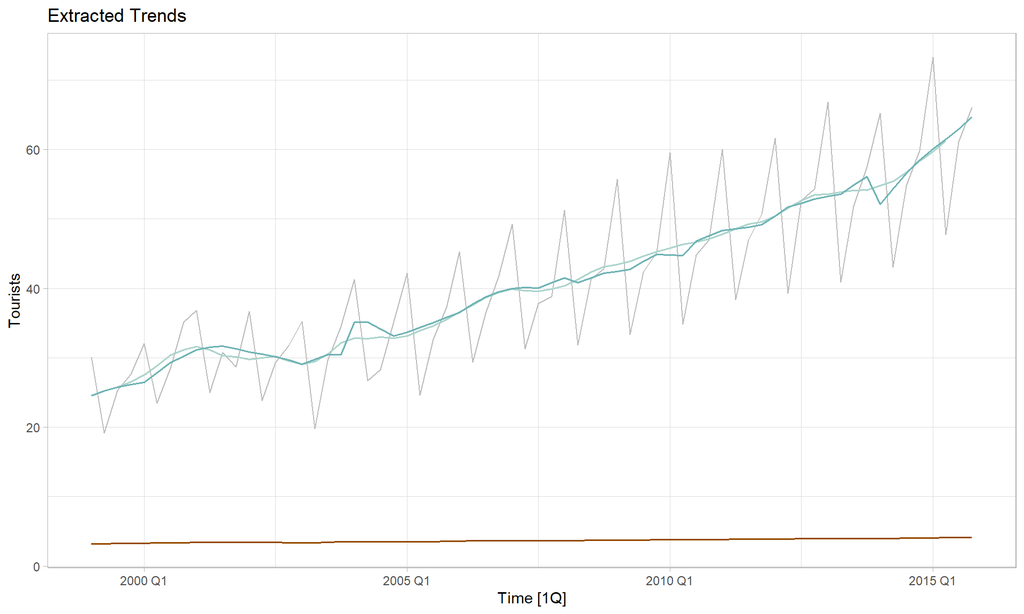

```r
# Plot data together with the trend (Anastasia's  code - TP 1)
tourist |>
  autoplot(Tourists, color = "grey") +
  autolayer(components(decomp_mult), trend, color = "#2F4858", size = .7) +
  autolayer(components(decomp_add), trend, color = "#ABD4CC", size = .7) +
  autolayer(components(decomp_stl_add), trend, color = "#6FB3B5", size = .7) +
  autolayer(components(decomp_stl_mult), trend, color = "#964B00", size = .7) +
  labs(title = "Extracted Trends") + theme_light()
```

**Note**: The classical multiplicative model is on top of the additive since they have the same trend. Therefore, only three trends are shown.

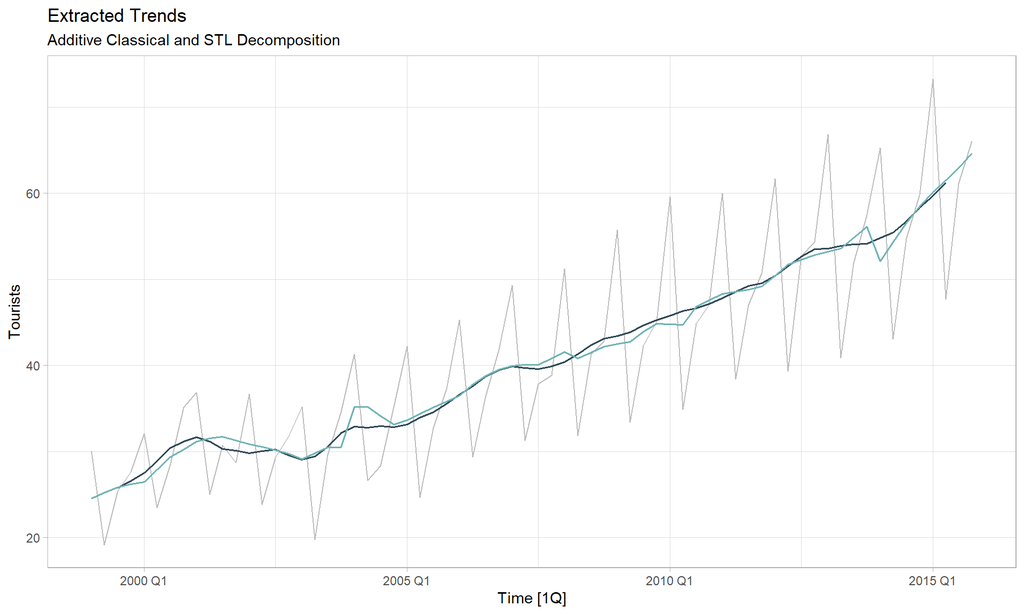

```r
# (Anastasia's  code - TP 1)
tourist |>
  autoplot(Tourists, color = "grey") +
  autolayer(components(decomp_add), trend, color = "#2F4858", size = .7) +
  autolayer(components(decomp_stl_add), trend, color = "#6FB3B5", size = .7) +
  labs(title = "Extracted Trends", subtitle = "Additive Classical and STL Decomposition") + theme_light()
```

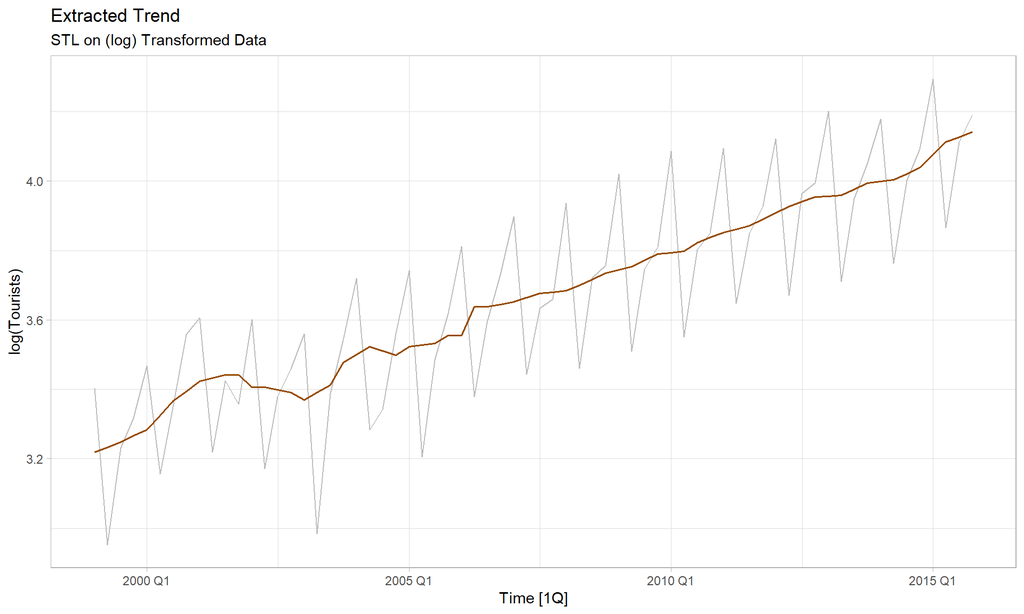

```r
# (Anastasia's  code - TP 1)
tourist |>
  autoplot(log(Tourists), color = "grey") +
  autolayer(components(decomp_stl_mult), trend, color = "#964B00", size = .7) +
  labs(title = "Extracted Trend" , subtitle = "STL on (log) Transformed Data") + theme_light()
```

Out of the four models, two of them have the same trend. Those would be the classical decompositions because they are both extracted by using the moving average approach. For the STL models, they need to be broken out onto two scales since the transformed data has smaller values. The reason why these trends differ from classical though is because it is estimated by the Loess method for nonlinear relationships. Unlike the classical methods, STL oversmoothes the data for those quarters that do not have values from the moving average.

## 3.4 Extracted Seasonality

```r
# Trend from additive decomposition
components(decomp_add) |>
  na.omit() |>
  select(Time, seasonal) -> addit_seasonal_coef

# Trend from multiplicative decomposition
components(decomp_mult) |>
  na.omit() |>
  select(Time, seasonal) -> mult_seasonal_coef

# Trend from STL additive decomposition
components(decomp_stl_add) |>
  na.omit() |>
  select(Time, season_year) -> stl_seasonal_coef

# Trend from STL multiplicative (log) decomposition
components(decomp_stl_mult) |>
  na.omit() |>
  select(Time, season_year) -> stl_log_seasonal_coef

bind_cols(addit_seasonal_coef,
          mult_seasonal_coef[,2],
          stl_seasonal_coef[3:66, 2],
          stl_log_seasonal_coef[3:66, 2])
```

```
## # A tsibble: 64 x 5 [1Q]
##       Time seasonal...2 seasonal...3 season_year...4 season_year...5
##      <qtr>        <dbl>        <dbl>           <dbl>           <dbl>
##  1 1999 Q3        -1.59        0.959          -0.841         -0.0167
##  2 1999 Q4         1.28        1.03            1.46           0.0687
##  3 2000 Q1         9.78        1.24            5.64           0.184
##  4 2000 Q2        -9.47        0.772          -6.29          -0.236
##  5 2000 Q3        -1.59        0.959          -0.851         -0.0167
##  6 2000 Q4         1.28        1.03            1.54           0.0687
##  7 2001 Q1         9.78        1.24            5.67           0.184
##  8 2001 Q2        -9.47        0.772          -6.58          -0.236
##  9 2001 Q3        -1.59        0.959          -0.968         -0.0170
## 10 2001 Q4         1.28        1.03            2.00           0.0684
## # … with 54 more rows
```

```r
# Note: Look at decomposition mult model, seasonal does has two NAs so 68 - 2 = 66
```

Extracting the seasonality helps to analyze the underlying fluctuations throughout the series, results are “seasonally adjusted”. Earlier within the classical decompositions, seasonality between the two models were constant. Here though, we see something slightly different because in the multiplicative method, the seasonal part is a proportion of the trend (Slide 95). The additive models are on the same scale and differ from the multiplicative methods.

# 4 Question C

Explore different models of ExponenTial Smoothing (ETS), comment your results and select the model that you consider the best in fitting the series. Argument your model’s choice and further justify it by performing a residuals analysis and validating the model’s assumptions using the required statistical testing procedures.

For each ETS method, there exists two models: one with additive errors and another with multiplicative errors. We will explore both as they generate different prediction intervals even though the point forecasts are identical if using the same smoothing parameter values. Although it is already known that the data contains trend and seasonality, some of these models will immediately not produce the best models (SES and Holt), but they are still explained to demonstrate the logic.

## 4.1 ETS(A, N, N): SES with Additive Errors

```r
tourist_ANN <-  tourist |>
  model(
    `SES_ANN` = ETS(Tourists ~ error("A") + trend("N") + season("N")))

report(tourist_ANN)
```

```
## Series: Tourists
## Model: ETS(A,N,N)
##   Smoothing parameters:
##     alpha = 0.1964325
##
##   Initial states:
##      l[0]
##  27.51182
##
##   sigma^2:  71.2746
##
##      AIC     AICc      BIC
## 581.0212 581.3962 587.6797
```

```r
fabletools::accuracy(tourist_ANN)
```

```
## # A tibble: 1 × 10
##   .model  .type       ME  RMSE   MAE   MPE  MAPE  MASE RMSSE   ACF1
##   <chr>   <chr>    <dbl> <dbl> <dbl> <dbl> <dbl> <dbl> <dbl>  <dbl>
## 1 SES_ANN Training  2.34  8.32  6.79  2.02  16.8  2.25  2.34 -0.309
```

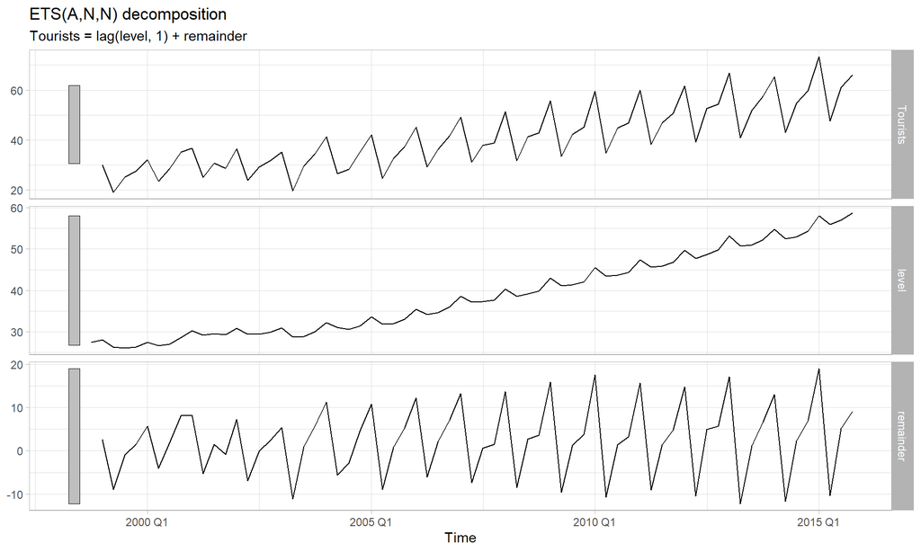

```r
components(tourist_ANN) |>  autoplot() + theme_light()
```

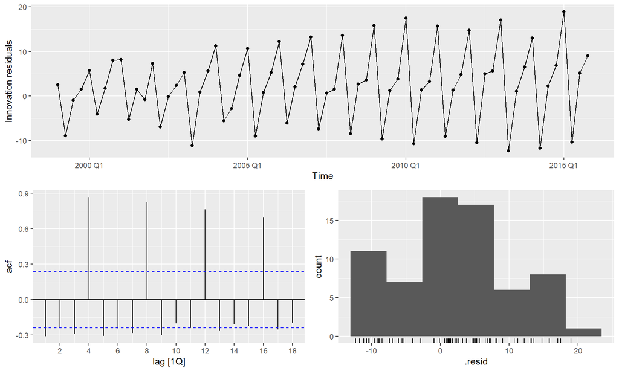

```r
# Extract residuals
residuals_tourist_ANN <- components(tourist_ANN)$remainder

# Residual plots
tourist_ANN |>  gg_tsresiduals()
```

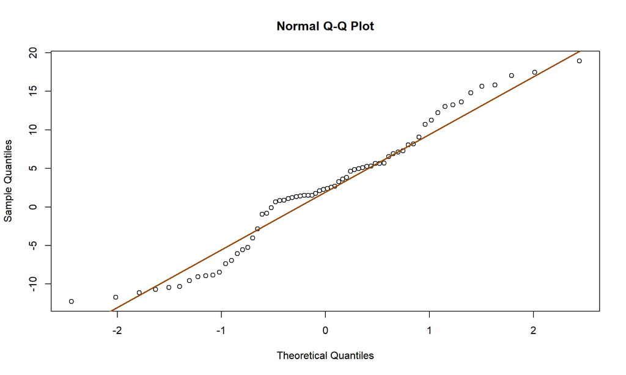

```r
# Normal qqplot of residuals
qqnorm(residuals_tourist_ANN)
qqline(residuals_tourist_ANN, col = "#964B00", lwd = 2)
```

```r
# Shapiro-Wilk test of normality
shapiro.test(residuals_tourist_ANN)
```

```
##
##  Shapiro-Wilk normality test
##
## data:  residuals_tourist_ANN
## W = 0.96625, p-value = 0.06227
```

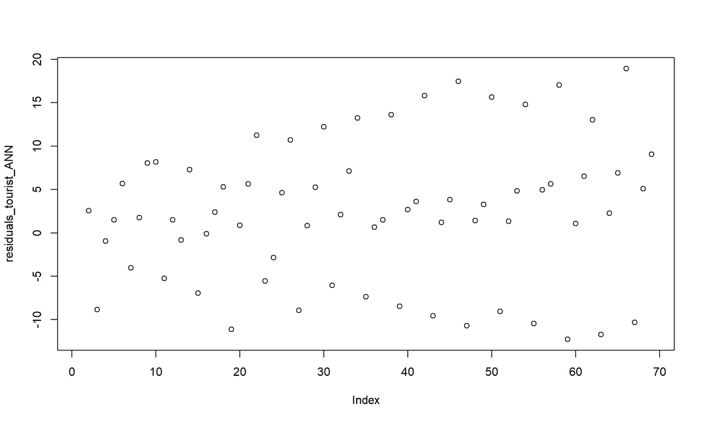

```r
# Scatterplot of residuals
plot(residuals_tourist_ANN)
```

```r
rm(residuals_tourist_ANN)
```

## 4.2 ETS(M, N, N): SES with Multiplicative Errors

```r
tourist_MNN <-  tourist |>
  model(
    `SES_MNN` = ETS(Tourists ~ error("M") + trend("N") + season("N")))

report(tourist_MNN)
```

```
## Series: Tourists
## Model: ETS(M,N,N)
##   Smoothing parameters:
##     alpha = 0.2059853
##
##   Initial states:
##      l[0]
##  27.13701
##
##   sigma^2:  0.0452
##
##      AIC     AICc      BIC
## 573.3785 573.7535 580.0370
```

```r
fabletools::accuracy(tourist_MNN)
```

```
## # A tibble: 1 × 10
##   .model  .type       ME  RMSE   MAE   MPE  MAPE  MASE RMSSE   ACF1
##   <chr>   <chr>    <dbl> <dbl> <dbl> <dbl> <dbl> <dbl> <dbl>  <dbl>
## 1 SES_MNN Training  2.27  8.32  6.80  1.88  16.9  2.25  2.35 -0.315
```

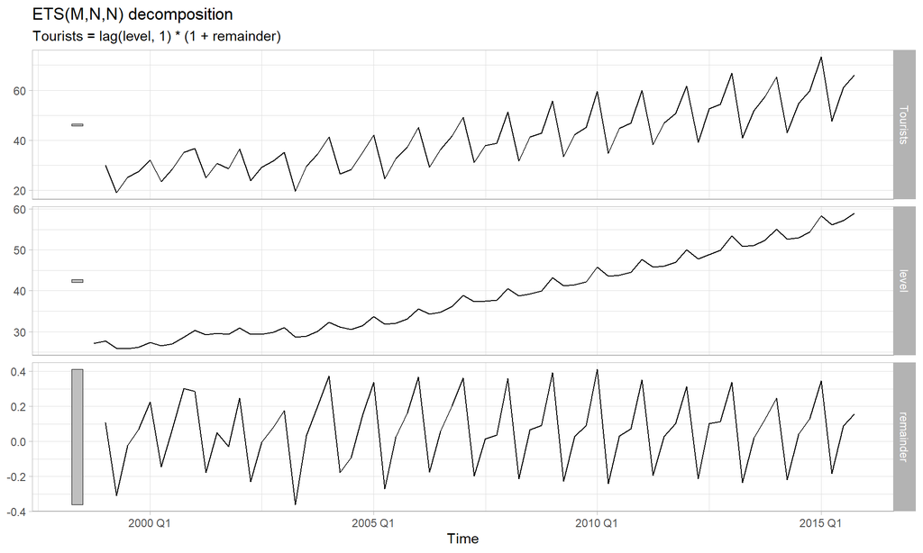

```r
components(tourist_MNN) |>  autoplot() + theme_light()
```

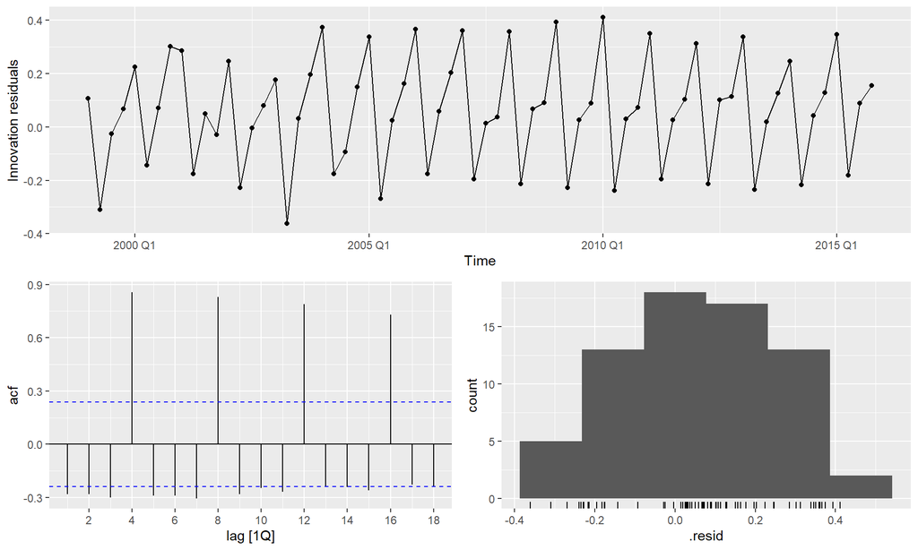

```r
# Extract residuals
residuals_tourist_MNN <- components(tourist_MNN)$remainder


# Residual plots
tourist_MNN |>  gg_tsresiduals()
```

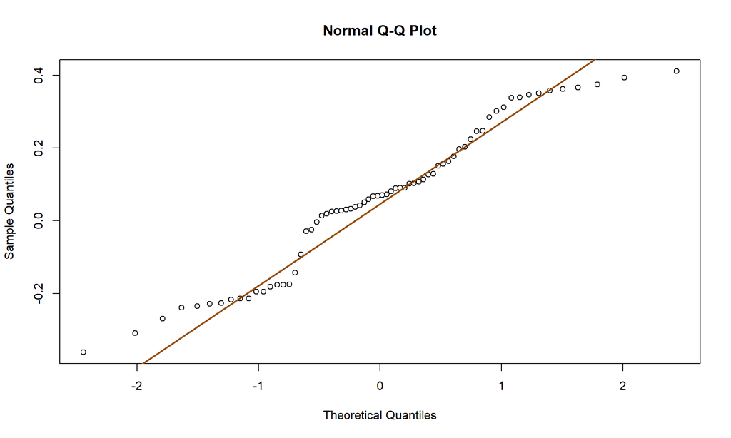

```r
# Normal qqplot of residuals
qqnorm(residuals_tourist_MNN)
qqline(residuals_tourist_MNN, col = "#964B00", lwd = 2)
```

```r
# Shapiro-Wilk test of normality
shapiro.test(residuals_tourist_MNN)
```

```
##
##  Shapiro-Wilk normality test
##
## data:  residuals_tourist_MNN
## W = 0.95607, p-value = 0.0175
```

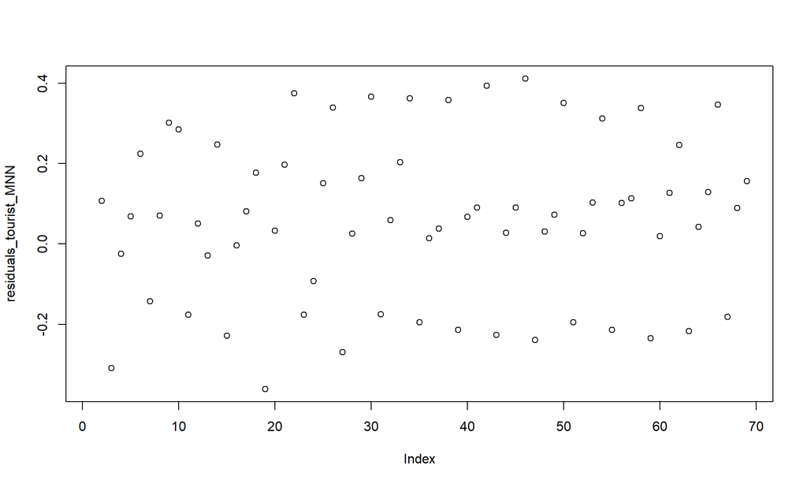

```r
# Scatterplot of residuals
plot(residuals_tourist_MNN)
```

```r
rm(residuals_tourist_MNN)
```

The simple exponential smoothing method is best suited for forecasting data with no obvious trend or seasonality. Between the two models, the better one in this scenario seems to be the SES(M,N,N) because it has a lower BIC measure. As a side note, we look at minimizing BIC because the chosen model is either the same as that chosen by the AIC, or has fewer terms. Both RMSE’s are around 8.32, and it is assumed that other models will be an improvement. Within these methods, there is a smoothing parameter, $\alpha$. If $\alpha$ is close to zero, more weight is given to observations from the more distant path. Those values that are closer to one though, will put more weight on more recent observations. The additive SES has an $\alpha$ of .196 while the multiplicative one has an $\alpha$ of .206. These would be more associated with the weights in the distant past.

**SES Component Form**: Only component included is level $l_t$.

• Forecast equation: $\hat{y}_{t+h|t} = l_t$  
• Level equation: $l_t = {\alpha}{y_t} + (1 - \alpha)l_{t-1}$

## 4.3 ETS(A, A, N): Holt’s Model

```r
tourist_AAN <-  tourist |>
  model(
    `Holt_AAN` = ETS(Tourists ~ error("A") + trend("A") + season("N")))

report(tourist_AAN)
```

```
## Series: Tourists
## Model: ETS(A,A,N)
##   Smoothing parameters:
##     alpha = 0.009743055
##     beta  = 0.009743028
##
##   Initial states:
##     l[0]    b[0]
##  25.1375 0.18333
##
##   sigma^2:  57.0636
##
##      AIC     AICc      BIC
## 567.8073 568.7751 578.9049
```

```r
fabletools::accuracy(tourist_AAN)
```

```
## # A tibble: 1 × 10
##   .model   .type       ME  RMSE   MAE    MPE  MAPE  MASE RMSSE   ACF1
##   <chr>    <chr>    <dbl> <dbl> <dbl>  <dbl> <dbl> <dbl> <dbl>  <dbl>
## 1 Holt_AAN Training 0.869  7.33  5.70 -0.735  14.6  1.89  2.07 -0.310
```

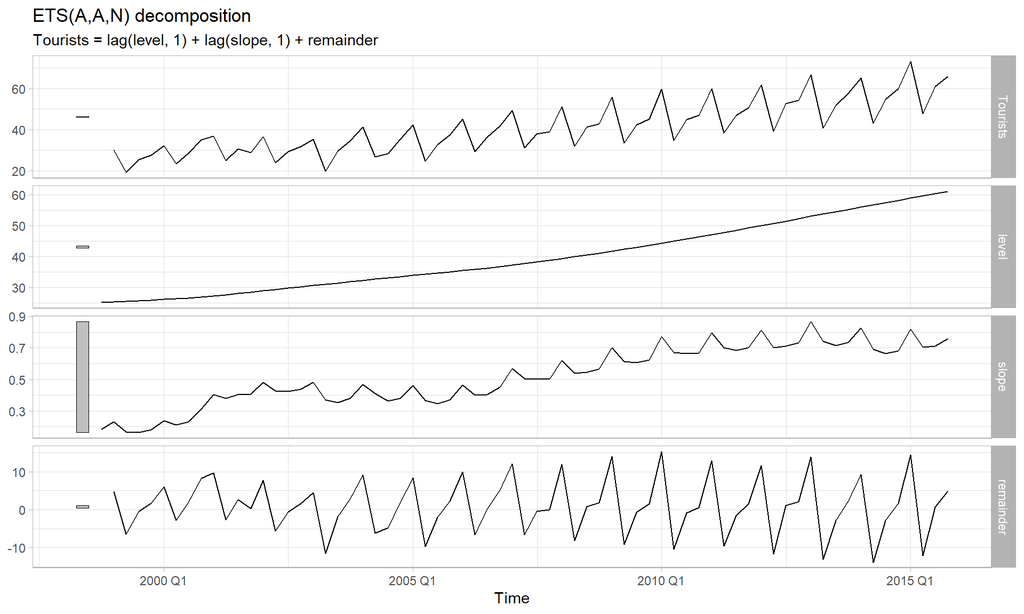

```r
components(tourist_AAN) |>  autoplot() + theme_light()
```

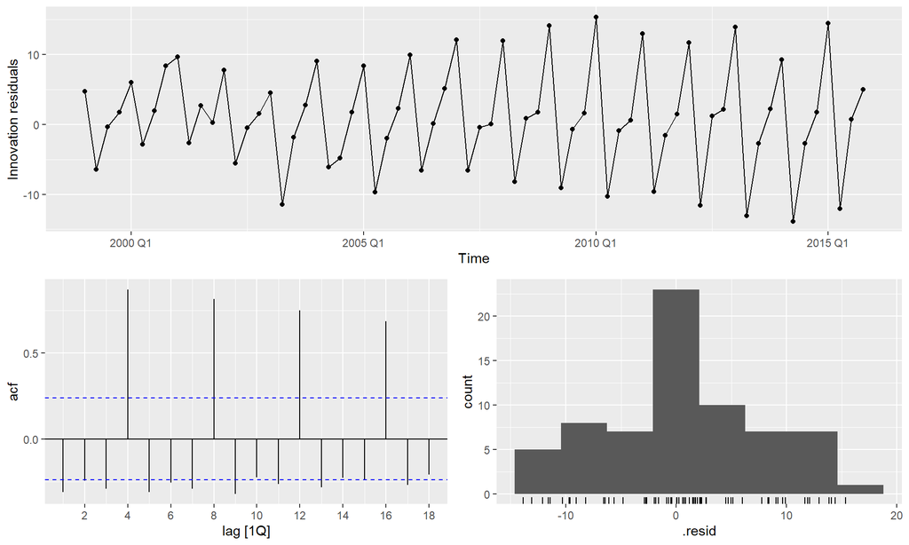

```r
# Extract residuals
residuals_tourist_AAN <- components(tourist_AAN)$remainder


# Residual plots
tourist_AAN |>  gg_tsresiduals()
```

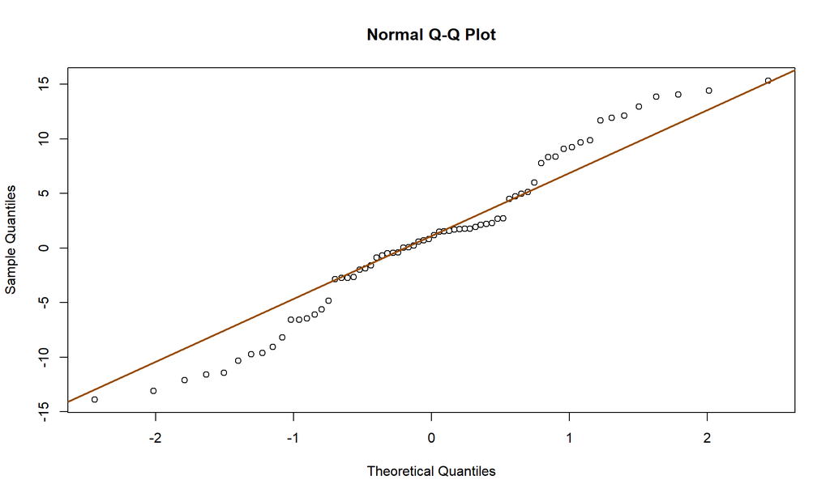

```r
# Normal qqplot of residuals
qqnorm(residuals_tourist_AAN)
qqline(residuals_tourist_AAN, col = "#964B00", lwd = 2)
```

```r
# Shapiro-Wilk test of normality
shapiro.test(residuals_tourist_AAN)
```

```
##
##  Shapiro-Wilk normality test
##
## data:  residuals_tourist_AAN
## W = 0.97248, p-value = 0.1372
```

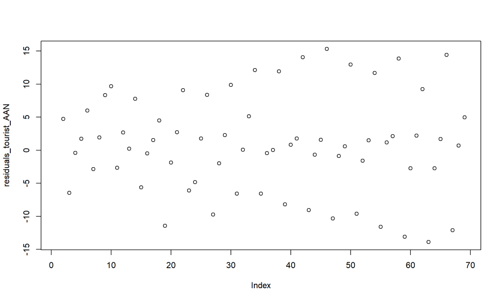

```r
# Scatterplot of residuals
plot(residuals_tourist_AAN)
```

```r
rm(residuals_tourist_AAN)
```

## 4.4 ETS(M, M, N): Holt’s Model

```r
tourist_MMN <-  tourist |>
  model(
    `Holt_MMN` = ETS(Tourists ~ error("M") + trend("M") + season("N")))

report(tourist_MMN)
```

```
## Series: Tourists
## Model: ETS(M,M,N)
##   Smoothing parameters:
##     alpha = 0.0664383
##     beta  = 0.0001000017
##
##   Initial states:
##      l[0]     b[0]
##  27.74359 1.012274
##
##   sigma^2:  0.034
##
##      AIC     AICc      BIC
## 564.5367 565.5044 575.6342
```

```r
fabletools::accuracy(tourist_MMN)
```

```
## # A tibble: 1 × 10
##   .model   .type        ME  RMSE   MAE   MPE  MAPE  MASE RMSSE   ACF1
##   <chr>    <chr>     <dbl> <dbl> <dbl> <dbl> <dbl> <dbl> <dbl>  <dbl>
## 1 Holt_MMN Training -0.152  7.48  5.86 -4.34  15.5  1.95  2.11 -0.307
```

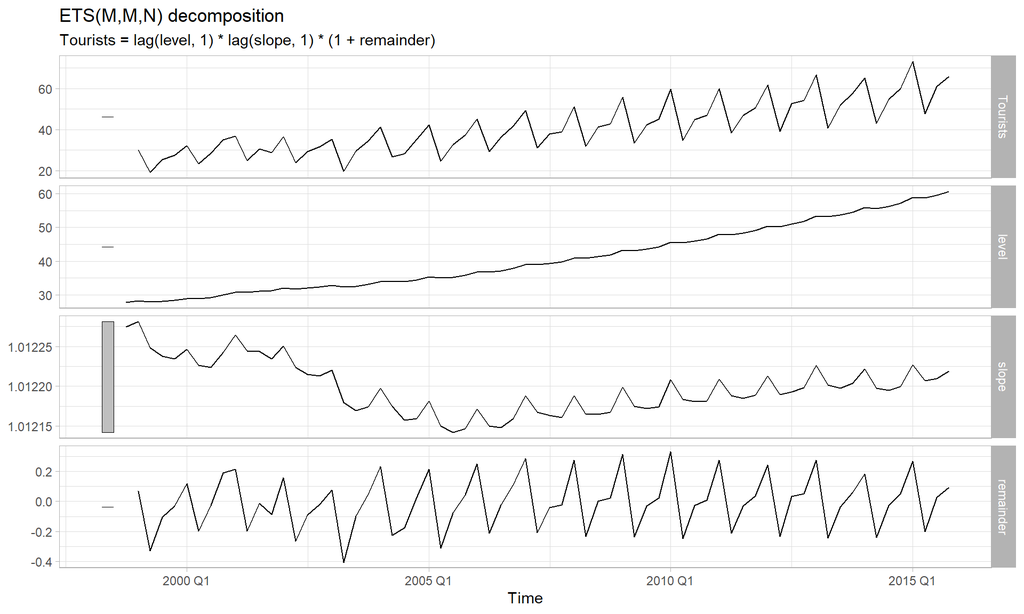

```r
components(tourist_MMN) |>  autoplot() + theme_light()
```

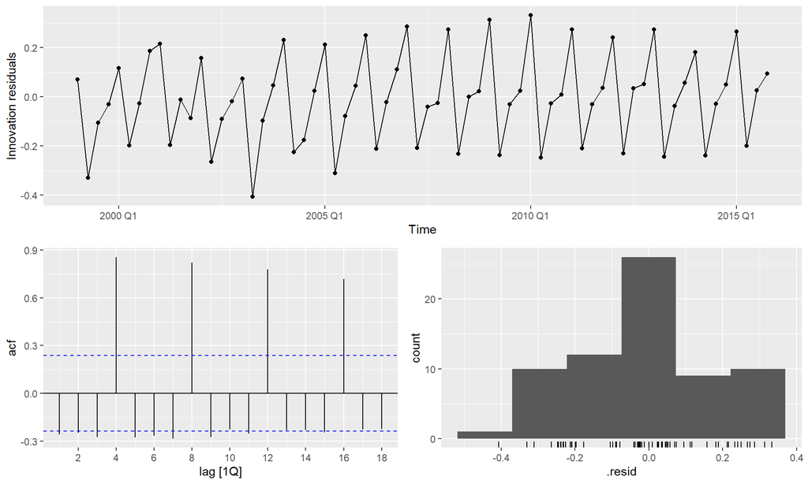

```r
# Extract residuals
residuals_tourist_MMN <- components(tourist_MMN)$remainder


# Residual plots
tourist_MMN |>  gg_tsresiduals()
```

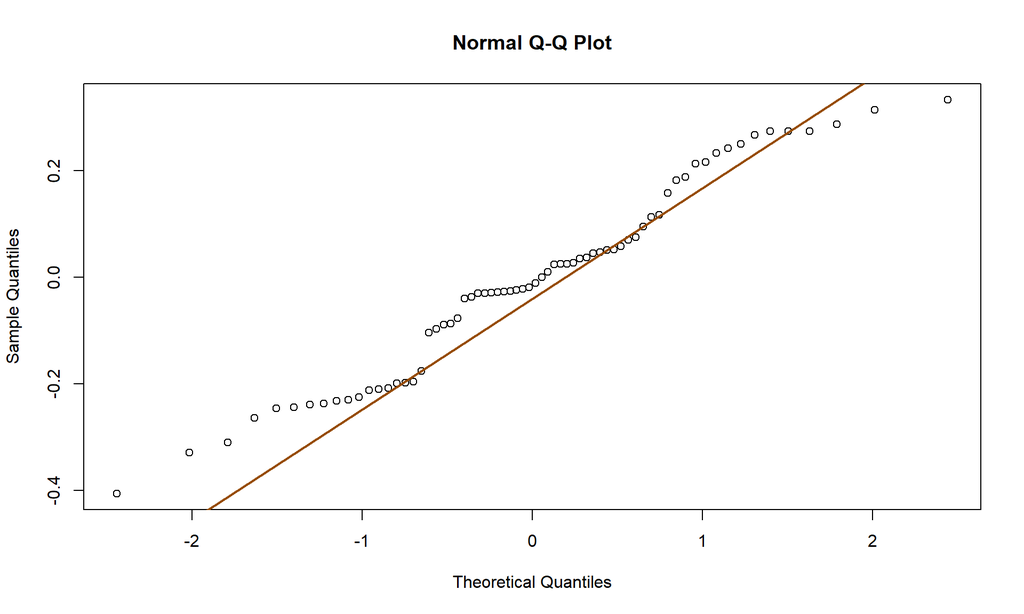

```r
# Normal qqplot of residuals
qqnorm(residuals_tourist_MMN)
qqline(residuals_tourist_MMN, col = "#964B00", lwd = 2)
```

```r
# Shapiro-Wilk test of normality
shapiro.test(residuals_tourist_MMN)
```

```
##
##  Shapiro-Wilk normality test
##
## data:  residuals_tourist_MMN
## W = 0.96723, p-value = 0.07047
```

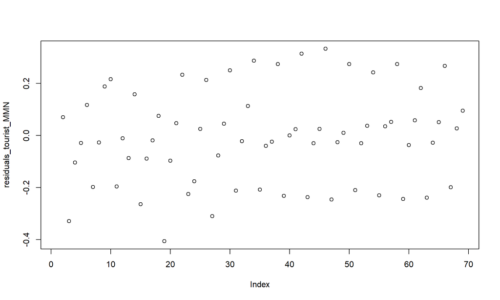

```r
# Scatterplot of residuals
plot(residuals_tourist_MMN)
```

```r
rm(residuals_tourist_MMN)
```

In Holt’s model, this allows the SES to be extended to include the trend within the forecast data. In practice, this means that the forecast function is not considered flat but is trending. According to the book, ’the $h$-step-ahead forecast is equal to the last estimated level plus $h$ times the last estimated trend value. Hence the forecasts are a linear function of $h$. In addition to the SES equations, Holt’s linear method introduces $\beta$, the slope.

Right away, we intuitively know that Holt’s model will be better than SES because it includes trend. If we compare to the previous two models, the BICs slightly dropped as did the RMSEs. It is interesting though because the RMSE of the multiplicative model is slightly higher than additive here. When looking at the multiplicative decomposition for classical and STL, these models seemed to fit better than additive. We will continue to explore.

Thee additional smoothing parameter for slope is $\beta$. Values close to 0 means that the trend does not change often in either model. $\alpha$ is very small too, indicating that the level does not change rapidly in order to capture the trended series. Since seasonality within the model is known and there are additional models to run, including a damped trend here will not be done at the moment. Instead, this constant trend will be discussed in the Holt Winter’s section.

As a quick recap, SES did not account for trend or seasonality, and Holt’s method only included trend. As seen throughout this entire analysis, trend and seasonality have been present. Therefore, there will be no additional measurements to consider.

Now, we dive into Holt-Winters method which captures seasonality. There is one more smoothing parameter, $\gamma$ which accounts for the seasonal component, $s_t$. According to Chapter 8.3, the additive method is preferred when the seasonal variations are roughly constant through the series, while the multiplicative method is used primarily when those variations are changing proportional to the level of the series. The additive model will express the seasonal component in absolute terms while the other will denote in relative terms (percentages). It has been acknowledged that the amplitude has been increasing over time, and therefore, we could assume this would be the best model out any previous method considered. To verify this, we run multiple Holt-Winters models and compare AIC, AICc, BIC, RMSE, and residuals (only for Holt-Winters methods) relative to all other models.